# COVID-19 Survey Analysis (Part 2: Data Extraction & Preprocessing)

Nathan K. Chan

**To visit this project on GitHub, please visit this link:** https://nathankchan.github.io/covid-19-survey-analysis/

*NB: Show or hide all code snippets using the* `Code` *button located in the upper right corner.*

**Please note that this report is under development and may be modified at a later time.**

### Table of Contents

1. **Preamble**
2. **Data extraction**
3. **Basic characterization**
4. **Data preprocessing**
5. **Appendix**

# 1. Preamble

This report section demonstrates an automated process to download data from [Harvard Dataverse](https://dataverse.harvard.edu/). We also examine the structure of the data and prepare it for analysis. Key topics discussed include *data cleaning* and *imputation of missing data*.

If you choose to follow along with code demonstrations, please initialize your environment by sourcing `00_init.R` and installing all required packages (see Part 1). Then, restart R and run the code block below.

```r
source(paste0(getwd(), "/scripts/02_cleandata.R"))
```

# 2. Data extraction

The **COVID-19 Behavior Determinants Database** can be accessed via Harvard Dataverse at doi.org/10.7910/DVN/NILCAV. To analyze this data, we will need to download the SPSS file `COVID-19 Behavior Determinants Database_v1.0.sav` and load this data into R.

The script `01_loaddata.R` automates the process of downloading and extracting data from Harvard Dataverse. Since scripts are nested, running `02_cleandata.R` will automatically source `00_init.R` to set up the environment and `01_loaddata.R` to load the data.

Data are loaded into a “tibble” (i.e., data frame) named `coviddata`.

# 3. Basic characterization

Let’s explore `coviddata` to understand what it contains. Using `dim()`, we can determine the dimensions of `coviddata` (i.e., the number of rows and columns it contains). We can also view the contents of `coviddata` for a qualitative perspective.

```r
dim(coviddata)
```

```
## [1] 8070  401
```

```r
head(coviddata)
```

| uuid | Primary_Case | OLD_uuid | Timepoint_1 | Timepoint_2 | Timepoint_3 | S2 | S3 | S3r6oe | S4 | S4r15oe | S5 | S5r15oe | S10A | S11A | S11C | S6A | S6B | S6Br7oe | S6C | S6D | S6E | S7A | S7Ar4oe | S7B | S7C | Weight | Height | States | US_Cities | … |
| --- | --- | --- | --- | --- | --- | --- | --- | --- | --- | --- | --- | --- | --- | --- | --- | --- | --- | --- | --- | --- | --- | --- | --- | --- | --- | --- | --- | --- | --- | --- |
| 0jzktntxmnzygekz | 1 |  | 1 | NA | NA | 1956 | 1 |  | 12 |  | 3 |  | 4 | 2 | 1 | 1 | 1 |  | House quiet neighborhood grea | 0 | NA | 3 |  | 0 | NA | NA | NA | NA | NA | … |
| 0ppw9gffd9e6mu3c | 1 |  | 1 | NA | NA | 1973 | 1 |  | 12 |  | 8 |  | 5 | 5 | 5 | 1 | 1 |  | vendors management | 0 | NA | 1 |  | 99 | NA | NA | NA | NA | NA | … |
| 10s2er0ydep720t5 | 1 |  | 1 | NA | NA | 2001 | 2 |  | 6 |  | 11 |  | 3 | 3 | 3 | 2 | 1 |  | student | 0 | NA | 2 |  | 0 | NA | NA | NA | NA | NA | … |
| 16jsts1afrjgvj1e | 1 |  | 1 | NA | NA | 1990 | 1 |  | 12 |  | 1 |  | 2 | 1 | 1 | 2 | 1 |  | telecom | 0 | NA | 1 |  | 0 | NA | NA | NA | NA | NA | … |
| 1vh5psphv074p501 | 1 |  | 1 | NA | NA | 1974 | 2 |  | 12 |  | 2 |  | 2 | 2 | 2 | 1 | 1 |  | unable to work | 0 | NA | 4 | unable to work | 0 | NA | NA | NA | NA | NA | … |
| 1vkvr9g1me01qdmg | 1 |  | 1 | NA | NA | 1962 | 1 |  | 12 |  | 1 |  | 2 | 99 | 99 | 2 | 3 |  | NA | 0 | NA | 0 |  | 0 | NA | NA | NA | NA | NA | … |

`dim()` shows that `coviddata` contains 8070 rows and 401 columns. Based on the table, rows may represent individual participants, whereas columns represent data collected from participants (e.g., survey responses, identifiers, etc.).

The contents of each column are not immediately obvious. For example, column “S2” likely describes years, but it is not clear if the data indicate year of birth or another time-related measure. Some columns appear to contain character strings (e.g., “S3r6oe”), whereas others seem to contain coded values (e.g., “S4”).

Fortunately, since SPSS files contain a data dictionary, we can identify columns contained in `coviddata`. Questions and values associated with each column were saved in the `label` and `labels` attributes of columns in `coviddata`.

For your convenience, these attributes were extracted into a list named `datadict`. Elements of `datadict` correspond to columns of `coviddata`, where each element contains the question, values, and table of counts for each value of a given column. Let’s investigate column “S5” and “S5r15oe”.

```r
datadict$S5
```

```
## $Question
## [1] "S5: What is your religion?"
##
## $Values
##            No religion         Roman Catholic          United Church
##                      1                      2                      3
##               Anglican                Baptist               Lutheran
##                      4                      5                      6
##                 Muslim           Presbyterian            Pentecostal
##                      7                      8                      9
##                 Jewish               Buddhist                  Hindu
##                     10                     11                     12
##                   Sikh         Greek Orthodox Other (please specify)
##                     13                     14                     15
##     I'd rather not say
##                     99
##
## $Table
## x
##    1    2    3    4    5    6    7    8    9   10   11   12   13   14   15   99
## 2516 2100  291  205  376  182  183  206  170  563  160   78   26   72  584  358
```

```r
datadict$S5r15oe
```

```
## $Question
## [1] "S5r15oe: What is your religion? - Other (please specify)"
##
## $Values
## NULL
##
## $Table
## x
##                                                       12 step
##                           7486                              1
##                    5 percenter                        7th day
##                              1                              1
##                      Adventist                       agnostic
##                              1                              5
##                       Agnostic                       AGNOSTIC
##                              5                              1
##                       Alliance                       Anglican
##                              2                              1
##                      APATHEIST                      Apostolic
##                              1                              1
##                         Asatru                        atheist
##                              1                              1
##                        Atheist                        athiest
##                              2                              1
##                    bahai faith                        Baptist
##                              1                              1
##                     born again                     Born Again
##                              2                              1
##           born again christian          Born Again Evangelist
##                              1                              1
##                       brethren                Casual Catholic
##                              2                              1
##                       catholic                       Catholic
##                              3                              5
##                    Charismatic                      chaustain
##                              1                              1
##                     Chiristian                         chirst
##                              1                              1
##                      christain                      Christain
##                              2                              1
```

[output cut: 169 more lines]

```
##                              1                              1
##                     sprititual                         taoist
##                              1                              1
##  The Church of Jesus Christ of                   TST satanism
##                              3                              1
##             ukrainian catholic             Ukrainian Catholic
##                              1                              2
##               United Methodist                          Unity
##                              7                              1
##                         wiccan                         Wiccan
##                              1                              7
##                     witchcraft                           yogi
##                              2                              1
##                    zoroastrian                    Zoroastrian
##                              1                              1
```

As can be seen above, column “S5” encodes the religion of the participant as a number. Numbers correspond to a look-up table containing labels. Thus, column “S5” is a categorical/nominal variable (or in R terms, a `factor`).

Meanwhile, column “S5r15oe” encodes the short-answer response of participants that answered “15” (i.e., “Other (please specify)”) to “S5”. Most participants did not respond to this question, and those that did respond provided custom answers. Thus, column “S5r15oe” is a column of qualitative responses.

Strictly speaking, it is possible to perform quantitative analysis of qualitative data using methods like natural language processing. However, such an analysis is outside the scope of this project. As such, the remainder of this project will focus on quantitative data (i.e., data that can be represented as a number). We will consider continuous, ordinal, and categorical/nominal variables, and we will exclude all qualitative variables.

# 4. Data preprocessing

The data require preparation for outlier and inferential analyses. Specifically, the data must

1. consist of values coercible to numeric (including categorical variables);
2. contain no missing values (i.e., no `NA` values); and
3. for inferential analyses specifically, contain no outliers.

The first two criteria are discussed below, while the third criterion is deferred to Part 3.

## 4.1. Select numeric data

We can meet the first criteria by filtering out all columns with data that cannot be coerced to numeric. Let’s call this new tibble `coviddata_num`.

```r
coviddata_num <- coviddata[, which(sapply(coviddata, is.numeric))]
```

## 4.2. Handling missing data

No missing data are permitted for upcoming analyses. While we could exclude all columns with missing data, this is an indiscriminate approach that limits the breadth of potential associations we will detect. It also could introduce bias if data are not missing at random. Instead, we should investigate the nature of the “missingness” and determine how to handle missing data on a case-by-case basis.

Missing data can be classified into three types:

1. **missing completely at random (MCAR)**, meaning that data are missing for reasons unrelated to observed or unobserved variables (e.g., participants randomly skipped questions about smoking status);
2. **missing at random (MAR)**, meaning that data are missing for known reasons that are unrelated to the variable of interest (e.g., smokers are less likely to complete a medical history survey vs. non-smokers, but the unobserved responses from missing smokers do not differ from the observed responses from responding smokers); and
3. **missing not at random (MNAR)**, meaning that data are missing for reasons related to the variable of interest itself (e.g., smokers with poorer health are less likely to complete a medical history survey, such that the set of responses from responding smokers is not representative of all smokers).

To handle the missing data, we have three options:

1. **exclude entire variables or cases** containing missing data;
2. **recode `NA` values** to some sensible values; or
3. **impute `NA` values** to ensure all cases are complete.

One option to investigate missingness is via visualization. Figure 1 depicts patterns of missing data in `coviddata_num` by plotting `NA` values on a heatmap. Yellow cells indicate missing values. Ultimately, our goal will be to minimize the amount of yellow in this plot.

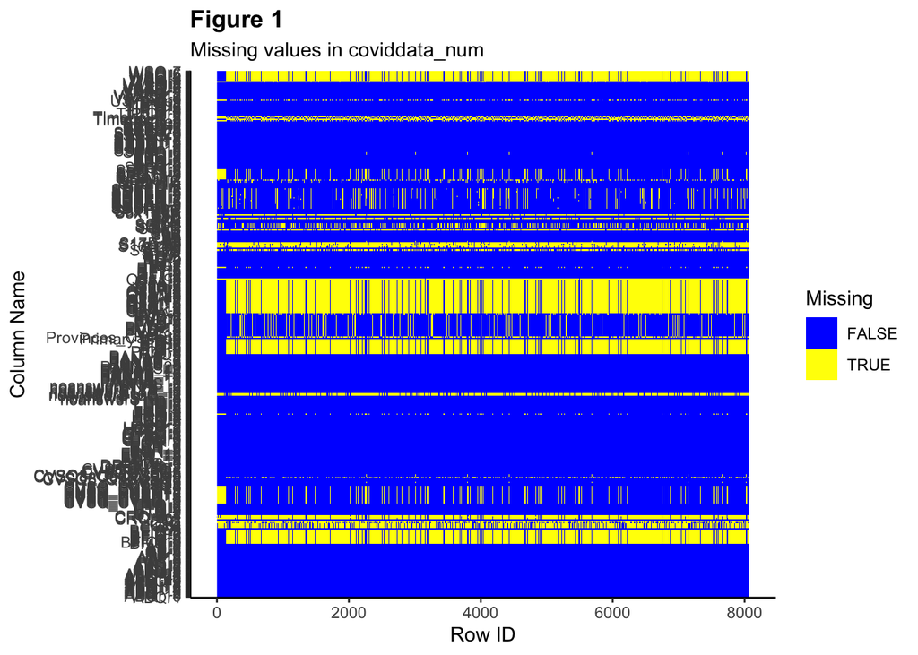

```r
plot_missing(coviddata_num, title = "Figure 1", subtitle = "Missing values in coviddata_num")
```

The horizontal yellow stripes suggest that some variables contain mostly missing values. Meanwhile, the vertical banding patterns suggest that some observations are missing by participant across one or more related variables.

Let’s try to untangle the structure of the missingness. We know that the data were collected at three discrete time points, and each case belongs to exactly one time point. The columns `Timepoint_1`, `Timepoint_2`, and `Timepoint_3` code this information as dummy variables, using `1` to indicate “yes” and `NA` to indicate “no” in the respective column. Since `NA` is effectively used to represent a “level” of a binary variable, let’s convert these `NA`s to `0`s. Then, let’s plot the missing values while sorting and marking values by Timepoint.

```r
# Timepoint variables are actually boolean; replace NA with 0 in each Timepoint
coviddata_num[-which(coviddata_num$Timepoint_1 == 1), "Timepoint_1"] <- 0
coviddata_num[-which(coviddata_num$Timepoint_2 == 1), "Timepoint_2"] <- 0
coviddata_num[-which(coviddata_num$Timepoint_3 == 1), "Timepoint_3"] <- 0
```

### 4.2.1. Missing variables by Timepoint

As seen in the figures below, certain variables are completely missing in each Timepoint. This is likely because some questions not were asked at all Timepoints (e.g., researchers added or removed survey questions at later Timepoints). Since these variables are empty, neither recoding nor imputation are possible. We will exclude these variables from further analysis.

The fourth tab shows missing values across the entire dataset after excluding variables completely missing at any Timepoint. Excluding these variables helped, and the amount of yellow in the plot is greatly reduced in Figure 5 compared to Figure 1. However, some missing values remain. Further investigation into the contents of the data with missing values is required.

#### Timepoint_1

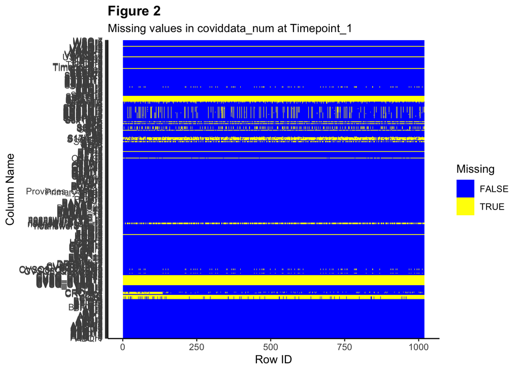

```r
coviddata_num[which(coviddata_num$Timepoint_1 == 1), ] %>% plot_missing(data = ., title = "Figure 2", subtitle = "Missing values in coviddata_num at Timepoint_1")
```

#### Timepoint_2

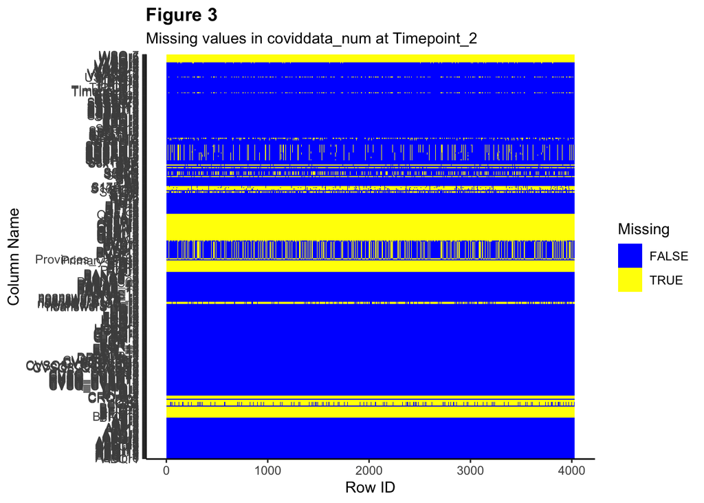

```r
coviddata_num[which(coviddata_num$Timepoint_2 == 1), ] %>% plot_missing(data = ., title = "Figure 3", subtitle = "Missing values in coviddata_num at Timepoint_2")
```

#### Timepoint_3

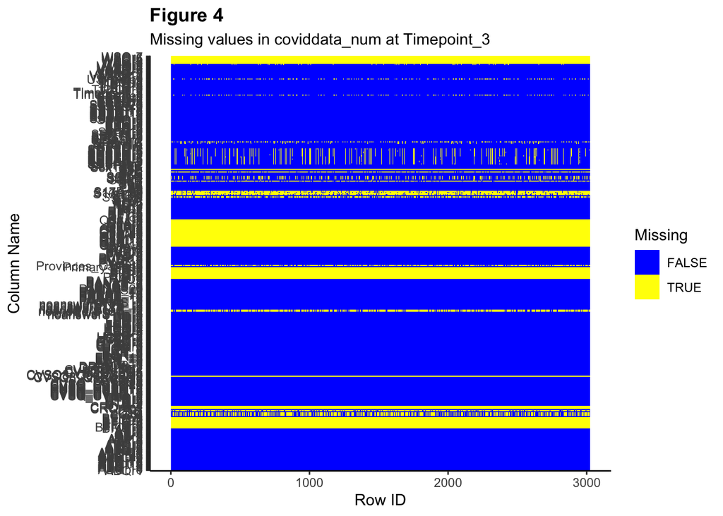

```r
coviddata_num[which(coviddata_num$Timepoint_3 == 1), ] %>% plot_missing(data = ., title = "Figure 4", subtitle = "Missing values in coviddata_num at Timepoint_3")
```

#### Variables completely missing by Timepoint excluded

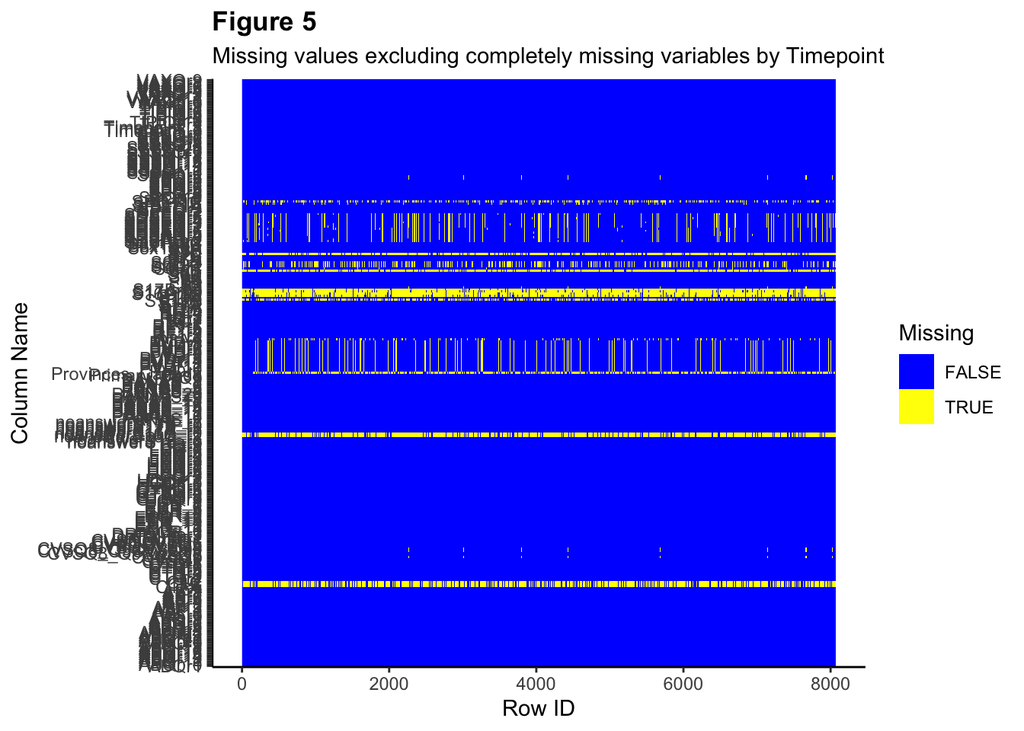

```r
vars_na1 <-
  coviddata_num %>%
  .[which(.$Timepoint_1 == 1),] %>%
  .[, which(sapply(., function(x) all(is.na(x))))] %>%
  names()
vars_na2 <-
  coviddata_num %>%
  .[which(.$Timepoint_2 == 1),] %>%
  .[, which(sapply(., function(x) all(is.na(x))))] %>%
  names()
vars_na3 <-
  coviddata_num %>%
  .[which(.$Timepoint_3 == 1),] %>%
  .[, which(sapply(., function(x) all(is.na(x))))] %>%
  names()

vars_naall <- unique(c(vars_na1, vars_na2, vars_na3))

coviddata_exclNA <- coviddata_num[, -which(names(coviddata_num) %in% vars_naall)]

plot_missing(data = coviddata_exclNA, title = "Figure 5", subtitle = "Missing values excluding completely missing variables by Timepoint")
```

### 4.2.2. Recoding values by variable

Yellow cells in Figure 5 indicate that missing values exist in the data. Similarly named variables are grouped together. Yellow vertical bands suggests that some participants did not respond to sets of related questions. The precise reason for missingness is not immediately clear, so we should determine how to handle missing data on a case-by-case basis.

At the same time, data that appear to be complete may still contain missing values! Recall the output of `datadict$S5` printed above. Under `$Values`, we can see that the value `99` is used when participants respond with `I'd rather not say`. In other words, `99` is an explicit code for nonresponses in column `S5`. These and similar nonresponses (e.g., `I don't know`, `Prefer not to answer`, etc.) essentially function as missing data in the variable.

**Thus, we will review** *every* **variable in the dataset and determine whether preprocessing is required.**

If `NA` values exist, we should determine if the `NA`s are MCAR, MAR. or MNAR. Variables with `NA`s that are MCAR or MAR should be identified, and in the next subsection, we will impute the missing values.

Meanwhile, `NA` values that are MNAR should be “repaired” if the reason for missingness is known. For example, the `NA` values in `S7C` (“Are you temporarily or permanently laid off?”) are “missing” because these participants answered `No` or `I'd rather not say` to `S7B` (“Have you been terminated/laid off because of COVID-19?”). In other words, the `NA` values in `S7C` are meaningful and indicate that the question is “Not applicable” to the participant. We should explicitly encode this type of “Not applicable” information as a level of the variable where possible (e.g., label as `0`).

This screening process will also give us an opportunity to classify each variable as either categorical, ordinal, or continuous. The variable type is important to identify, as it affects methods for imputation and preprocessing of correspondence analysis data.

Let’s generate a data dictionary of extant variables from `coviddata_exclNA` (which excludes empty variables identified in the previous section). Then, let’s review the output of `datadict_exclNA`.

```r
datadict_exclNA <- sapply(coviddata_exclNA, get_var_info, simplify = F)

# At some point I'll figure out a more elegant solution for displaying the data dictionary through Shiny; for now, just print the entire object out.
print(datadict_exclNA)
```

```
## $Primary_Case
## $Primary_Case$Question
## NULL
##
## $Primary_Case$Values
##  No Yes
##   0   1
##
## $Primary_Case$Table
## x
##    0    1
##  392 7678
##
##
## $Timepoint_1
## $Timepoint_1$Question
## [1] "Timepoint_1: Survey timepoint 1"
##
## $Timepoint_1$Values
## T1
##  1
##
## $Timepoint_1$Table
## x
##    0    1
## 7051 1019
##
##
## $Timepoint_2
## $Timepoint_2$Question
## [1] "Timepoint_2: Survey timepoint 2"
##
## $Timepoint_2$Values
## T2
##  1
##
## $Timepoint_2$Table
## x
##    0    1
## 4043 4027
```

[output cut: 4518 more lines]

```
##  190  177  427 2104 2150 1784 1238
##
##
## $ECR_16
## $ECR_16$Question
## [1] "ECR_16: I resent it when people with whom I feel close spend time away from me. - The following statements concern how you feel in close relationships with others. In the following statements the term “other people” refers to people with whom you feel"
##
## $ECR_16$Values
## Disagree1         2         3  Neutral4         5         6    Agree7
##         1         2         3         4         5         6         7
##
## $ECR_16$Table
## x
##    1    2    3    4    5    6    7
## 1754 1188  982 2360  887  523  376
```

Next, let’s categorize variables by type, plan the necessary preprocessing steps, then perform preprocessing.

```r
attach(coviddata_exclNA)

# Put all categorical variables that do not need preprocessing here
vars_cat <- bind_cols(
  "Timepoint_1"     = Timepoint_1,      # Identifier for time when survey collected
  "Timepoint_2"     = Timepoint_2,      # Identifier for time when survey collected
  "Timepoint_3"     = Timepoint_3,      # Identifier for time when survey collected
  "S6A"             = S6A,              # Relationship status
  "S6D"             = S6D,              # Health care worker (y/n)
  "RF1r1"           = RF1r1,            # Have heart disease (y/n)
  "RF1r2"           = RF1r2,            # Have hypertension (y/n)
  "RF1r3"           = RF1r3,            # Have lung disease (y/n)
  "RF1r4"           = RF1r4,            # Have diabetes (y/n)
  "RF1r5"           = RF1r5,            # Have cancer (y/n)
  "RF1r6"           = RF1r6,            # Have chronic kidney disease (y/n)
  "RF1r7"           = RF1r7,            # Have obesity (y/n)
  "RF2"             = RF2,              # Have weakened immune system (y/n)
  "ASr1"            = ASr1,             # Have fever/chills/shakes (y/n)
  "ASr2"            = ASr2,             # Have cough (y/n)
  "ASr3"            = ASr3,             # Have shortness of breath (y/n)
  "ASr4"            = ASr4,             # Have tired or fatigued(y/n)
  "ASr5"            = ASr5,             # Have lost appetite (y/n)
  "ASr6"            = ASr6,             # Have muscle aches and pains (y/n)
  "ASr7"            = ASr7,             # Have nasal congestion (y/n)
  "ASr8"            = ASr8,             # Have sore throat (y/n)
  "ASr9"            = ASr9,             # Have excessive sputum (y/n)
  "ASr10"           = ASr10,            # Have lost smell (y/n)
  "ASr11"           = ASr11,            # Have lost taste (y/n)
  "ASr12"           = ASr12,            # Have diarrhea (y/n)
  "ASr13"           = ASr13,            # Have other symptoms (y/n)
  "C1"              = C1,               # Ever tested for COVID-19 (y/n)
  "CVSQ1"           = CVSQ1,            # Source of health information (incl. other)
  "CVSQ2"           = CVSQ2,            # Belief of origin of COVID-19 (incl. other)
  "CVSQ3"           = CVSQ3,            # Had COVID/what was outcome
  "CVSQCVSQ4"       = CVSQCVSQ4,        # Close family member or friend that is health care worker (y/n)
  "CVSQCVSQ5"       = CVSQCVSQ5,        # Close family member or friend that is high risk (y/n)
  "CVSQCVSQ6"       = CVSQCVSQ6,        # Close family member or friend in senior's residence (y/n)
  "CVSQCVSQ7"       = CVSQCVSQ7,        # Close family member or friend in long-term care (y/n)
  "noanswerS15_r0"  = noanswerS15_r0,   # cat; Number of drinks in last 7 days (non-drinkers)
  "noanswerS15_r1"  = noanswerS15_r1,   # cat; Number of drinks in last 7 days (less than 1 per week)
  "noanswerS15_r2"  = noanswerS15_r2,   # cat; Number of drinks in last 7 days (it depends)
  "S16A"            = S16A,             # Use of cannabis products (combine with below)
  "noanswerS17A_r0" = noanswerS17A_r0,  # cat; Number of cigarettes (non-smokers)
  "noanswerS17A_r1" = noanswerS17A_r1,  # cat; Number of cigarettes (less than 1 per day)
  "noanswerS17A_r2" = noanswerS17A_r2,  # con; Number of cigarettes (it depends)
  "noanswerS17B_r0" = noanswerS17B_r0,  # cat; Number of e-cigarettes (non-users)
  "noanswerS17B_r1" = noanswerS17B_r1,  # cat; Number of e-cigarettes (less than 1 per day)
  "noanswerS17B_r2" = noanswerS17B_r2   # cat; Number of e-cigarettes (it depends)
)

# Put all ordinal variables that do not need preprocessing here
vars_ord <- bind_cols(
  "S10A"          = S10A,                 # Highest level of education
  "S8x1S8A"       = S8x1S8A,              # Income reduced by COVID-19
  "S8x1S8B"       = S8x1S8B,              # In financial distress
  "S8x1S8C"       = S8x1S8C,              # Trouble making ends meet
  "SPFQr1"        = SPFQr1,               # Comply with social distancing (avoid groups)
  "SPFQr2"        = SPFQr2,               # Comply with social distancing (maintain 6ft distance in community)
  "SPFQr3"        = SPFQr3,               # Comply with social distancing (keep distance from people at risk)
  "SPQr1"         = SPQr1,                # Stay at home unless for work
  "SPQr2"         = SPQr2,                # Avoid non-essential trips
  "SPQr3"         = SPQr3,                # Keep distance if leaving home
  "SPQr4"         = SPQr4,                # Limit close contacts with people at high risk
  "SPQr5"         = SPQr5,                # Avoid crowded places
  "SPQr6"         = SPQr6,                # Avoid common greetings (hugging and kissing)
  "SPQr7"         = SPQr7,                # Disinfect hands often
  "SPQr8"         = SPQr8,                # Wash or disinfect hands for at least 20 seconds
  "SPQr9"         = SPQr9,                # Cough or sneeze into bend of arm
  "SPQr10"        = SPQr10,               # Avoid touching eyes, nose, mouth
  "SPQ11A"        = SPQ11A,               # Exercise frequency
  "SSSQr1"        = SSSQr1,               # Easily influenced by people's opinions
  "SSSQr2"        = SSSQr2,               # Easily influenced by commercials
  "SSSQr3"        = SSSQr3,               # Likely to cough or sneeze when seeing others do so
  "SSSQr4"        = SSSQr4,               # Imagining drink can make me thirsty
  "SSSQr5"        = SSSQr5,               # Salesperson can make me want their product
  "SSSQr6"        = SSSQr6,               # Practical advice from magazines or TV
  "SSSQr7"        = SSSQr7,               # Nicely displayed product makes me want to buy
  "SSSQr8"        = SSSQr8,               # Seeing shiver makes me feel a chill
  "SSSQr9"        = SSSQr9,               # Get style from celebrities
  "SSSQr10"       = SSSQr10,              # Feel same feelings when others share feelings
  "SSSQr11"       = SSSQr11,              # Follow other people's advice when making decisions
  "SSSQr12"       = SSSQr12,              # Reading tasty descriptions of dishes makes mouth water
  "SSSQr13"       = SSSQr13,              # Get good ideas from others
  "SSSQr14"       = SSSQr14,              # Frequently change opinions after talking with others
  "SSSQr15"       = SSSQr15,              # Lotion commercials make skin feel dry
  "SSSQr16"       = SSSQr16,              # Discover favorite things from friends
  "SSSQr17"       = SSSQr17,              # Follow current fashion trends
  "SSSQr18"       = SSSQr18,              # Thinking about scary makes heart pound
  "SSSQr19"       = SSSQr19,              # Pick up habits from friends
  "SSSQr20"       = SSSQr20,              # Feel ill if told don't look well
  "SSSQr21"       = SSSQr21,              # Important to fit in
  "RQr1"          = RQr1,                 # Saftey first
  "RQr2"          = RQr2,                 # Do not take risks with my health
  "RQr3"          = RQr3,                 # Avoid risks
  "RQr4"          = RQr4,                 # Regularly take risks
  "RQr5"          = RQr5,                 # Dislike not knowing what is going to happen
  "RQr6"          = RQr6,                 # View risks as a challenge
  "RQ7"           = RQ7,                  # Risk avoider vs risk seeker
  "DRIQInfor1"    = DRIQInfor1,           # Experience presence of divine
  "DRIQInfor2"    = DRIQInfor2,           # Religious/spiritual beliefs lie behind whole approach to life
  "DRIQInfor3"    = DRIQInfor3,           # Try hard to carry religious/spiritual beliefs into all dealings in life
  "TIPIQr1"       = TIPIQr1,              # Extroverted or enthusiastic
  "TIPIQr2"       = TIPIQr2,              # Critical or quarrelsome
  "TIPIQr3"       = TIPIQr3,              # Dependable or self-disciplined
  "TIPIQr4"       = TIPIQr4,              # Anxious or easily upset
  "TIPIQr5"       = TIPIQr5,              # Open to new experiences or complex
  "TIPIQr6"       = TIPIQr6,              # Reserved or quiet
  "TIPIQr7"       = TIPIQr7,              # Sympathetic or warm
  "TIPIQr8"       = TIPIQr8,              # Disorganized or careless
  "TIPIQr9"       = TIPIQr9,              # Calm or emotionally stable
  "TIPIQr10"      = TIPIQr10,             # Conventional or un-creative
  "CTQr1"         = CTQr1,                # All levels of government are capable concerning COVID-19
  "CTQr2"         = CTQr2,                # All levels of government are experts concerning COVID-19
  "CTQr3"         = CTQr3,                # All levels of government carry duties out well concerning COVID-19
  "CTQr4"         = CTQr4,                # All levels of government will do their best to help citizens concerning COVID-19
  "CTQr5"         = CTQr5,                # All levels of government act in the interest of citizens concerning COVID-19
  "CTQr6"         = CTQr6,                # All levels of government are interested in the well-being of citizens concerning COVID-19
  "CTQr7"         = CTQr7,                # All levels of government approach citizens in sincere ways concerning COVID-19
  "CTQr8"         = CTQr8,                # All levels of government are honest concerning COVID-19
  "HCQr1"         = HCQr1,                # Positive thinking can help fight off minor illness
  "HCQr2"         = HCQr2,                # Alternative/holistic medicine should be subject to more scientific testing
  "HCQr3"         = HCQr3,                # Important to be careful about lifestyle when stressed
  "HCQr4"         = HCQr4,                # Alternative/holistic medicine can be dangerous by preventing people getting proper treatment
  "HCQr5"         = HCQr5,                # Symptoms of illness made worse by depression
  "HCQr6"         = HCQr6,                # Alternative/holistic medicine used only as last resort
  "HCQr7"         = HCQr7,                # Stressful life events increase likelihood of illness
  "HCQr8"         = HCQr8,                # Worthwhile to try complementary medicine before seeing doctor
  "HCQr9"         = HCQr9,                # Conflict with others has no effect on health
  "HCQr10"        = HCQr10,               # Alternative/holistic medicine only used for minor ailments and not serious illness
  "HCQr11"        = HCQr11,               # Important to find balance between work and relaxation to stay healthy
  "HCQr12"        = HCQr12,               # Alternative/holistic medicine builds up body's defenses leading to permanent cure
  "LCQr1"         = LCQr1,                # Life is determined by own actions
  "LCQr2"         = LCQr2,                # Able to protect personal interests
  "LCQr3"         = LCQr3,                # Can determine what will happen in my life
  "LCQr4"         = LCQr4,                # Life controlled by accidental findings
  "LCQr5"         = LCQr5,                # No chance of protecting personal interest from bad luck
  "LCQr6"         = LCQr6,                # I get what I want because I'm lucky
  "LCQr7"         = LCQr7,                # Little chance of protecting personal interests when conflict with strong pressure groups
  "LCQr8"         = LCQr8,                # Life chiefly controlled by powerful others
  "LCQr9"         = LCQr9,                # Feel like what happens in life determined by powerful people
  "VAXQr1"        = VAXQr1,               # Feel safe after vaccination
  "VAXQr2"        = VAXQr2,               # Rely on vaccines to stop serious infectious diseases
  "VAXQr3"        = VAXQr3,               # Feel protected after getting vaccinated
  "VAXQr4"        = VAXQr4,               # Vaccines appear safe but have problems not yet discovered
  "VAXQr5"        = VAXQr5,               # Vaccines can cause unforeseen problems in children
  "VAXQr6"        = VAXQr6,               # Worry about unknown effects of vaccines in future
  "VAXQr7"        = VAXQr7,               # Vaccines make a lot of money for pharmaceutical companies
  "VAXQr8"        = VAXQr8,               # Authorities promote vaccination for financial gain not health
```

```r
  "VAXQr9"        = VAXQr9,               # Vaccination programs are a big con
  "VAXQr10"       = VAXQr10,              # Natural immunity lasts longer than vaccination
  "VAXQr11"       = VAXQr11,              # Natural exposure to viruses and germs gives safest protection
  "VAXQr12"       = VAXQr12,              # Exposed to diseases naturally safer for immune system vs vaccination
  "GTSQr1"        = GTSQr1,               # Most people are basically honest
  "GTSQr2"        = GTSQr2,               # Most people are trustworthy
  "GTSQr3"        = GTSQr3,               # Most people are basically good and kind
  "GTSQr4"        = GTSQr4,               # Most people are trustful of others
  "GTSQr5"        = GTSQr5,               # I am trustful
  "GTSQr6"        = GTSQr6,               # Most people respond in kind when they are trusted by others
  "PAQ1"          = PAQ1,                 # Political spectrum (communism to fascism)
  "ABQr1"         = ABQr1,                # Listen to older people about how to behave
  "ABQr2"         = ABQr2,                # Question judgment of umpires or referees
  "ABQr3"         = ABQr3,                # Do what authoritative figures tell you to do
  "ABQr4"         = ABQr4,                # Criticize people who are rude to superiors
  "ABQr5"         = ABQr5,                # Encourage young people to do what they want even if against parents wishes
  "ABQr6"         = ABQr6,                # Dress to be acceptable to people that run the place
  "ABQr7"         = ABQr7,                # Treat experts with respect even when you don't think much of them personally
  "ABQr8"         = ABQr8,                # Support left-wing radical policies
  "ABQr9"         = ABQr9,                # Take part in demonstrations to show opposition to policies you do not like
  "ABQr10"        = ABQr10,               # Express approval for work of school teachers
  "ABQr11"        = ABQr11,               # Go to church
  "ABQr12"        = ABQr12,               # Make fun of police
  "ABQr13"        = ABQr13,               # Look for guidance from someone wiser
  "ABQr14"        = ABQr14,               # Sympathize with rebels
  "ABQr15"        = ABQr15,               # Break speed limit or encourage driver to do so if safe when in hurry
  "ABQr16"        = ABQr16,               # Follow doctor's orders
  "ABQr17"        = ABQr17,               # Question what you hear on news
  "ABQr18"        = ABQr18,               # Cross road against pedestrian traffic lights
  "ABQr19"        = ABQr19,               # Ask for a second opinion when uncertain about doctor's advice
  "ABQr20"        = ABQr20,               # Stand when playing national anthem in public
  "ABQr21"        = ABQr21,               # Express contempt for politicians
  "ABQr22"        = ABQr22,               # Annoyed when people sneer at those in authority
  "ABQr23"        = ABQr23,               # Show special respect for people in high positions
  "ABQr24"        = ABQr24,               # Speak up against boss when acting unfairly
  "CVSQ8_Q9CVSQ8" = CVSQ8_Q9CVSQ8,        # Willing to get vaccinated against COVID-19
  "PANAS_1"       = PANAS_1,              # Interested
  "PANAS_2"       = PANAS_2,              # Distressed
  "PANAS_3"       = PANAS_3,              # Excited
  "PANAS_4"       = PANAS_4,              # Upset
  "PANAS_5"       = PANAS_5,              # Strong
  "PANAS_6"       = PANAS_6,              # Guilty
  "PANAS_7"       = PANAS_7,              # Scared
  "PANAS_8"       = PANAS_8,              # Hostile
  "PANAS_9"       = PANAS_9,              # Enthusiastic
  "PANAS_10"      = PANAS_10,             # Proud
  "PANAS_11"      = PANAS_11,             # Irritable
  "PANAS_12"      = PANAS_12,             # Alert
  "PANAS_13"      = PANAS_13,             # Ashamed
  "PANAS_14"      = PANAS_14,             # Inspired
  "PANAS_15"      = PANAS_15,             # Nervous
  "PANAS_16"      = PANAS_16,             # Determined
  "PANAS_17"      = PANAS_17,             # Attentive
  "PANAS_18"      = PANAS_18,             # Jittery
  "PANAS_19"      = PANAS_19,             # Active
  "PANAS_20"      = PANAS_20,             # Afraid
  "ECR_1"         = ECR_1,                # Uncomfortable when other people want to be close
  "ECR_2"         = ECR_2,                # Worry about feeling abandoned
  "ECR_3"         = ECR_3,                # Tell people whom I feel close just about everything
  "ECR_4"         = ECR_4,                # Need reassurance that I am loved
  "ECR_5"         = ECR_5,                # Don't feel comfortable opening up to other people
  "ECR_6"         = ECR_6,                # Worry a lot about relationships
  "ECR_7"         = ECR_7,                # Discuss problems and concerns with people close to me
  "ECR_8"         = ECR_8,                # Find that other people don't want to get as close as I would like
  "ECR_9"         = ECR_9,                # Avoid getting too close to other people
  "ECR_10"        = ECR_10,               # Worry that other people won't care about me as much as I care about them
  "ECR_11"        = ECR_11,               # Don't mind asking other people about comfort, advice, or help
  "ECR_12"        = ECR_12,               # Get frustrated when other people are not around as much as I would like
  "ECR_13"        = ECR_13,               # Prefer not to be too close to other people
  "ECR_14"        = ECR_14,               # Worry a fair about about losing people I feel close to
  "ECR_15"        = ECR_15,               # Helps to turn to other people in times of need
  "ECR_16"        = ECR_16                # Resent when people I am close to spend time away from me
)

# Put all continuous variables that do not need preprocessing here
vars_con <- bind_cols(
  "S2" = S2 # Year of birth
)

vars_dealwithlater <- bind_cols(
  "Provinces_Canada" = Provinces_Canada  # cat; Province (for Canadian responses, incl. NA for US)
)

vars_excl <- bind_cols(
  "Primary_Case" = Primary_Case,      # Unknown (incl. NA)
  "C1AA"         = C1AA              # ord; When tested for COVID-19 (incl. 99 for missing; too many NA)
)
```